# DS 6306 Project 1

# Question 6

### Comment on the summary statistics and distribution of the ABV variable.

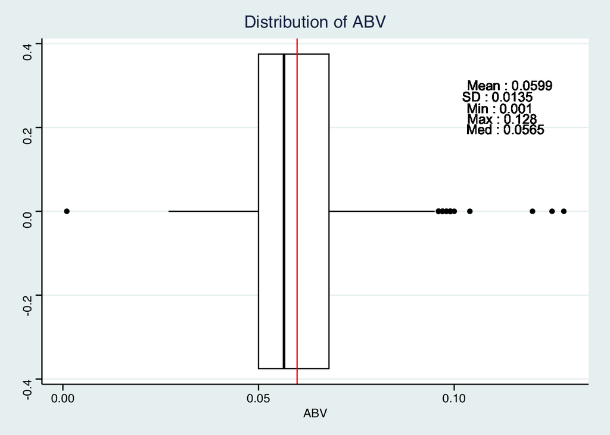

```r
library(ggplot2)
library(dplyr)
library(hrbrthemes)
library(viridis)
beer_data %>% filter(!is.na(ABV)) %>%
  ggplot(aes(x=ABV)) +
  geom_boxplot(color="black") +
  geom_vline(aes(xintercept= mean(ABV)), color ="red") +
  geom_text(aes(mean(ABV), 0, label=paste("Mean :",round(mean(ABV), digits= 4)), vjust = -12.7, hjust = -1.99)) +
  geom_text(aes(mean(ABV), 0, label=paste("SD :",round(sd(ABV), digits= 4)), vjust = -11.5, hjust = -2.34)) +
  geom_text(aes(mean(ABV), 0, label=paste("Min :",round(min(ABV), digits= 4)), vjust = -10.3, hjust = -2.57)) +
  geom_text(aes(mean(ABV), 0, label=paste("Max :",round(max(ABV), digits= 4)), vjust = -9.2, hjust = -2.44)) +
  geom_text(aes(mean(ABV), 0, label=paste("Med :",round(median(ABV), digits= 4)), vjust = -8.1, hjust = -2.17)) +
  ggtitle("Distribution of ABV") +
  ylab(NULL) +
  theme_stata()
```

The output is a box plot that shows the distribution of ABV (Alcohol by Volume) values in the beer data set. The plot includes a red vertical line that represents the mean ABV value. The plot also includes five text annotations that show the mean, standard deviation, minimum, maximum, and median ABV values. The plot is informative and easy to read. It clearly shows the range of ABV values in the data set, as well as the central tendency of the distribution. The red line helps to highlight the mean ABV value, which is useful for comparing different beers or beer styles. Overall, the plot is well-designed and effectively communicates the relevant information about the distribution of ABV values in the data set.

# Question 7

### Is there an apparent relationship between the bitterness of the beer and its alcoholic content? Draw a scatter plot. Make your best judgment of a relationship and EXPLAIN your answer.

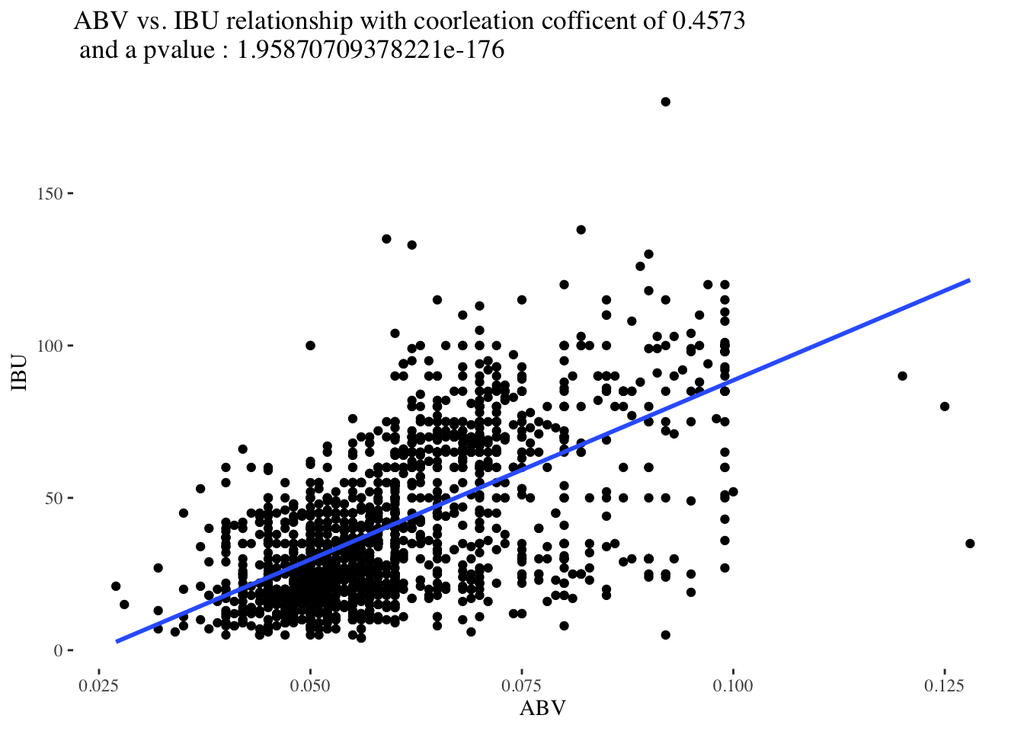

```r
beer_data %>% filter(!is.na(ABV) & !is.na(IBU)) %>%
  ggplot(aes(x= ABV, y= IBU)) +
  geom_point() +
  geom_smooth(method=lm, se=FALSE) +
  ggtitle(paste0("ABV vs. IBU relationship with coorleation cofficent of ", round(cor.test(beer_data$ABV,beer_data$IBU, method="kendall")$estimate, digits = 4), "\n and a pvalue : ", ... = cor.test(beer_data$ABV,beer_data$IBU, method="kendall")$p.value) ) +
  theme_tufte()
```

```r
cor.test(beer_data$ABV, beer_data$IBU)[3]
```

```
## $p.value
## [1] 2.028497e-191
```

# Question 8

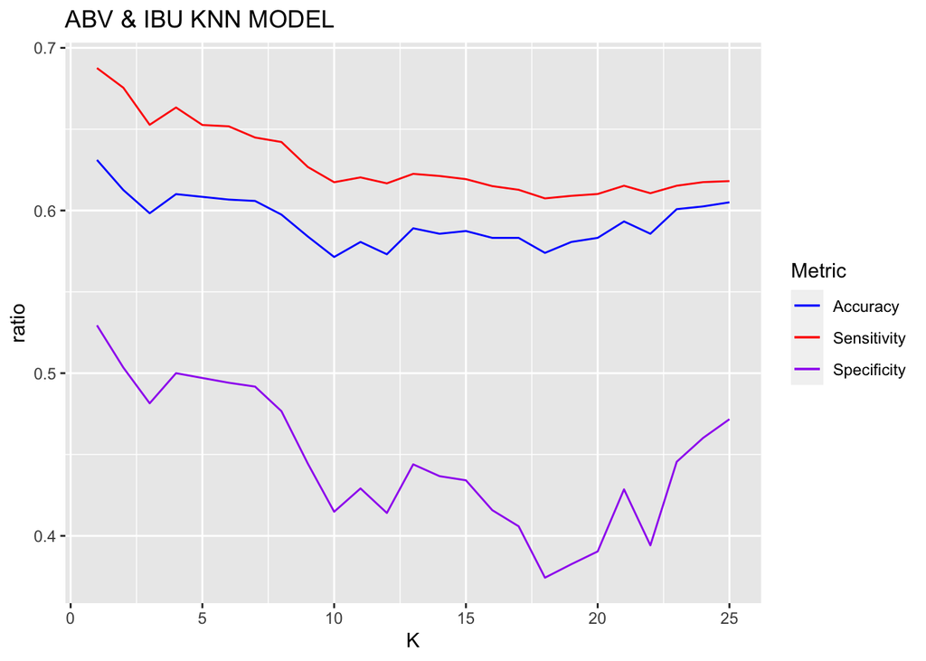

```r
library(class)
library(e1071)
library(ggplot2)
library(dplyr)
library(caret)
# filtering for rows with non missing values in ABV and IBU that contain the substring 'IPA' or 'Ale', from there it is encoded to a new
# column of type containing either the string 'IPA' or 'Ale'
beer_knn_dataset = beer_data %>%
  filter(!is.na(ABV) & !is.na(IBU) & (grepl('Ale', Style) | grepl('IPA', Style))) %>%
  mutate(Type = ifelse(!grepl('Ale', Style) ,'IPA', 'Ale'))

#creating dataframes for metrics
accs = data.frame(accuracy = numeric(25), k = numeric(25))
sens = data.frame(sensitivity = numeric(25), k = numeric(25))
spec = data.frame(specificity = numeric(25), k = numeric(25))
#Figuring out which K value to us
for(i in 1:25)
{
  #Knn cross validation model
  classifications = knn.cv(beer_knn_dataset[,c(3,5)],beer_knn_dataset$Type, prob = TRUE, k = i, use.all = FALSE)
  #creating a table
  table(beer_knn_dataset$Type,classifications)
  #Confusion Matrix
  CM = confusionMatrix(table(beer_knn_dataset$Type,classifications))
  #Adding the metrics to their perspective dataframes
  accs$accuracy[i] = CM$overall[1]
  sens$sensitivity[i] = CM$byClass[1]
  spec$specificity[i] = CM$byClass[2]
  #adding k value to dataframes
  accs$k[i] = i
  sens$k[i] = i
  spec$k[i] = i
}
#Plotting the metrics
ggplot() +
  geom_line(data = accs, aes(k,accuracy,  colour ="Accuracy")) +
  geom_line(data = sens ,aes(k,sensitivity,  colour ="Sensitivity")) +
  geom_line(data = spec, aes(k,specificity, colour = "Specificity")) +
  ggtitle("ABV & IBU KNN MODEL") +
  ylab("ratio") +
  xlab("K") +
  scale_color_manual(values = c("Accuracy" = "blue", "Sensitivity" = "red", "Specificity" = "purple")) +
  labs(color = "Metric")
```

```r
#KNN Cross validation model
classifications = knn.cv(beer_knn_dataset[,c(3,5)],beer_knn_dataset$Type, prob = TRUE, k = 5, use.all=FALSE)
#Creating a Table
table(beer_knn_dataset$Type,classifications)
```

```
##      classifications
##       Ale IPA
##   Ale 560 166
##   IPA 295 169
```

```r
#Confusion Matrix
CM = confusionMatrix(table(beer_knn_dataset$Type,classifications))
CM
```

```
## Confusion Matrix and Statistics
##
##      classifications
##       Ale IPA
##   Ale 560 166
##   IPA 295 169
##
##                Accuracy : 0.6126
##                  95% CI : (0.5843, 0.6404)
##     No Information Rate : 0.7185
##     P-Value [Acc > NIR] : 1
##
##                   Kappa : 0.1427
##
##  Mcnemar's Test P-Value : 2.498e-09
##
##             Sensitivity : 0.6550
##             Specificity : 0.5045
##          Pos Pred Value : 0.7713
##          Neg Pred Value : 0.3642
##              Prevalence : 0.7185
##          Detection Rate : 0.4706
##    Detection Prevalence : 0.6101
##       Balanced Accuracy : 0.5797
##
##        'Positive' Class : Ale
##
```

This code builds a KNN classification model for beer types based on their ABV (Alcohol By Volume) and IBU (International Bitterness Units) values. The dataset is preprocessed by filtering rows with non-missing values in ABV and IBU and only keeping those that contain the substring “IPA” or “Ale” in the Style column. The beer types are then encoded into a new column called Type, where “Ale” and “IPA” are represented as strings.

The code then performs a loop to find the optimal K value for the KNN model by fitting the model using different values of K, generating classification results, and evaluating the accuracy, sensitivity, and specificity metrics of the model using cross-validation. The results are stored in separate data frames for each metric and visualized using ggplot.

Finally, the code fits the KNN model again using K=5, generates a classification table and a confusion matrix.

Overall, the code is well-organized and easy to follow. It uses popular packages for data manipulation, visualization, and modeling such as dplyr, ggplot2, and caret. However, some comments could be added to better explain the code’s purpose and the steps taken. Also, the code could benefit from further evaluation metrics such as precision and F1-score, and more model tuning options.

# Question 9

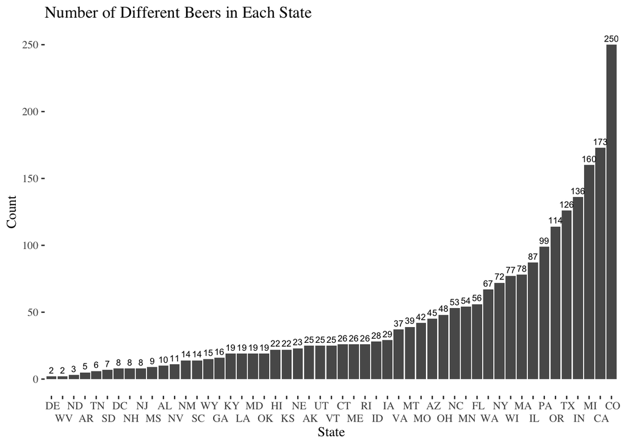

```r
library(ggthemes)
number_beers = beer_data %>% count(State)
number_beers %>% ggplot(aes(x=reorder(State, +n), y=n)) +
  geom_bar(stat = "identity") +
  xlab("State") +
  ylab("Count") +
  ggtitle("Number of Different Beers in Each State") +
  scale_x_discrete(guide = guide_axis(n.dodge=2)) +
  geom_text(aes(label=n), vjust=-0.5, color="black",
            position = position_dodge(0.9), size=2.5) +
  theme_tufte()
```

```r
top_beers =distinct(beer_data %>% group_by(State) %>% top_n(1, Style) %>% select(State, Style), State, .keep_all =TRUE)

top_beers <- top_beers %>% group_by(Style) %>% count(Style)
top_beers
```

```
## # A tibble: 15 × 2
## # Groups:   Style [15]
##    Style                         n
##    <chr>                     <int>
##  1 "American Pale Ale (APA)"     2
##  2 "English Brown Ale"           1
##  3 "Herbed / Spiced Beer"        1
##  4 "K\xf6lsch"                   1
##  5 "Oatmeal Stout"               3
##  6 "Rye Beer"                    1
##  7 "Saison / Farmhouse Ale"      8
##  8 "Schwarzbier"                 2
##  9 "Scotch Ale / Wee Heavy"      2
## 10 "Scottish Ale"                1
## 11 "Shandy"                      1
## 12 "Tripel"                      1
## 13 "Vienna Lager"                3
## 14 "Winter Warmer"               1
## 15 "Witbier"                    23
```

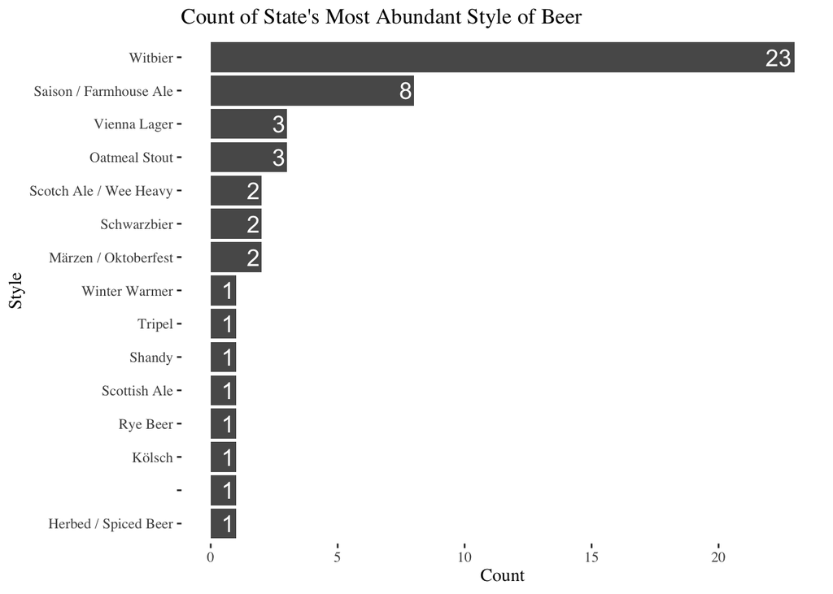

```r
top_beers$Style[1] = "Märzen / Oktoberfest"
top_beers$Style[2] = "Kölsch"
top_beers %>% ggplot(aes(y=reorder(Style, +n), x=n)) + geom_bar(stat="identity") + geom_text(aes(label=n), color="white",
          hjust=1.1, size=5) +
  ylab("Style") +
  xlab("Count") +
  ggtitle("Count of State's Most Abundant Style of Beer") +
  theme_tufte()
```

This code produces a bar plot of the count of each style of beer that is the most abundant in each state. The plot is sorted in descending order of the count of each style. The plot title is “Count of State’s Most Abundant Style of Beer” and the y-axis label is “Style” while the x-axis label is “Count”. The plot is formatted using the Tufte style. Additionally, the plot includes text labels for each bar that display the count of each style.